# Qualitative Activity Prediction of Weight Lifting Exercises

## Background

Information for this project is sourced from the Weight Lifting Exercise Dataset section of http://groupware.les.inf.puc-rio.br/har.

We are provided with training and testing datasets. These contain data from accelerometers on the belt, forearm, arm, and dumbell of 6 participants who were asked to perform barbell lifts correctly and incorrectly in 5 different classes namely:

A. Exactly according to specification B. Throwing the elbows to the front C. Lifting the dumbbell only halfway D. Lowering the dumbbell only halfway E. Throwing the hips to the front

### Question

The goal is to predict the manner (classe variable in dataset) in which the participants did the exercise for the testing dataset. In the process, we will have to explain the choice of our model and its features.

## Loading the libraries required.

```r
library(caret)
library(dplyr)
library(randomForest)
library(e1071)
library(rattle)
library(rpart)
```

```r
library(rpart.plot)
```

## Input

Loading the training and testing datasets

```r
setwd("C:/Users/rohit/Desktop/Coursera Data Science Specialization/Practical machine learning")
if (!file.exists("training.csv")){
  url="https://d396qusza40orc.cloudfront.net/predmachlearn/pml-training.csv"
  download.file(url, "training.csv")
}

if (!file.exists("testing.csv")){
  url="https://d396qusza40orc.cloudfront.net/predmachlearn/pml-testing.csv"
  download.file(url, "testing.csv")
}

training=read.csv("training.csv",  na.strings=c("", "NA", "#DIV/0!"))
testing=read.csv("testing.csv",  na.strings=c("", "NA", "#DIV/0!"))
```

## Features

Removing variables with more than 50% missing values

```r
rmv_cols_NA=training[colMeans(is.na(training))>0.50]
clean_data=training[,-which( names(training) %in% names(rmv_cols_NA ))]
```

Removing variables related to timestamp, window, and user name that are not required for the question namely:

```r
names(clean_data[1,1:7])
```

```
## [1] "X"                    "user_name"            "raw_timestamp_part_1"
## [4] "raw_timestamp_part_2" "cvtd_timestamp"       "new_window"
## [7] "num_window"
```

```r
clean_data=clean_data[,8:ncol(clean_data)]
clean_data_numeric=data.frame(apply(clean_data[,-53],2, as.numeric))
clean_data=cbind(clean_data_numeric,select(clean_data,classe ))
```

There are no variables with near zero variance.

```r
nzv=nearZeroVar(clean_data)
length(nzv)
```

```
## [1] 0
```

Splitting the training dataset into training and validation

```r
set.seed(12123)
inTrain=createDataPartition(y=clean_data$classe, p=0.6, list=F)
training=clean_data[inTrain,]
validation=clean_data[-inTrain,]
```

[output not shown]

## Algorithm and Evaluation

### Recursive Partitioning and Regression trees algorithm

I expect the out of sample error rate to be 0.02 or less, i.e. the Accuracy ~98%. The accuracy for this model is ~75% which is not impressive.

```r
modFit1=rpart(classe~.,data=training, method="class")
pred1=predict(modFit1, validation, type="class")
print(confusionMatrix(pred1, validation$classe))
```

```
## Confusion Matrix and Statistics
##
##           Reference
## Prediction    A    B    C    D    E
##          A 1940  183   12   54   67
##          B   78 1037  138  127  167
##          C   98  139 1032  188   99
##          D   84  107   96  826   73
##          E   32   52   90   91 1036
##
## Overall Statistics
##
##                Accuracy : 0.7483
##                  95% CI : (0.7385, 0.7579)
##     No Information Rate : 0.2845
##     P-Value [Acc > NIR] : < 2.2e-16
##
##                   Kappa : 0.6815
##  Mcnemar's Test P-Value : < 2.2e-16
##
## Statistics by Class:
##
##                      Class: A Class: B Class: C Class: D Class: E
## Sensitivity            0.8692   0.6831   0.7544   0.6423   0.7184
## Specificity            0.9437   0.9194   0.9191   0.9451   0.9586
## Pos Pred Value         0.8599   0.6703   0.6632   0.6965   0.7963
## Neg Pred Value         0.9478   0.9236   0.9466   0.9309   0.9380
## Prevalence             0.2845   0.1935   0.1744   0.1639   0.1838
## Detection Rate         0.2473   0.1322   0.1315   0.1053   0.1320
## Detection Prevalence   0.2875   0.1972   0.1983   0.1512   0.1658
## Balanced Accuracy      0.9064   0.8013   0.8367   0.7937   0.8385
```

Using varImp, we can rate the predictors by their importance and keep only the ones necessary.

```r
vars=varImp(modFit1)
keep=rownames(vars)[vars$Overall>0]
```

With this, the number of predictors have reduced to

```
## [1] 34
```

### Random forest algorithm

The accuracy for this model is 99% however there are 34 predictors and we would like to reduce this number.

```r
training=training[,c(keep, "classe")]
modFit2=randomForest(classe~., data=training, type="class")
modFit2
```

```
##
## Call:
##  randomForest(formula = classe ~ ., data = training, type = "class")
##                Type of random forest: classification
##                      Number of trees: 500
## No. of variables tried at each split: 5
##
##         OOB estimate of  error rate: 0.8%
## Confusion matrix:
##      A    B    C    D    E class.error
## A 3344    3    1    0    0 0.001194743
## B   19 2251    9    0    0 0.012286090
## C    0   20 2029    5    0 0.012171373
## D    0    0   23 1904    3 0.013471503
## E    0    1    6    4 2154 0.005080831
```

```r
pred2=predict(modFit2, validation, type="class")
print(confusionMatrix(pred2, validation$classe))
```

```
## Confusion Matrix and Statistics
##
##           Reference
## Prediction    A    B    C    D    E
##          A 2226   14    0    0    0
##          B    1 1498    9    0    0
##          C    4    6 1356   15    2
##          D    1    0    3 1268    5
##          E    0    0    0    3 1435
##
## Overall Statistics
##
##                Accuracy : 0.992
##                  95% CI : (0.9897, 0.9938)
##     No Information Rate : 0.2845
##     P-Value [Acc > NIR] : < 2.2e-16
##
##                   Kappa : 0.9898
##  Mcnemar's Test P-Value : NA
##
## Statistics by Class:
##
##                      Class: A Class: B Class: C Class: D Class: E
## Sensitivity            0.9973   0.9868   0.9912   0.9860   0.9951
## Specificity            0.9975   0.9984   0.9958   0.9986   0.9995
## Pos Pred Value         0.9938   0.9934   0.9805   0.9930   0.9979
## Neg Pred Value         0.9989   0.9968   0.9981   0.9973   0.9989
## Prevalence             0.2845   0.1935   0.1744   0.1639   0.1838
## Detection Rate         0.2837   0.1909   0.1728   0.1616   0.1829
## Detection Prevalence   0.2855   0.1922   0.1763   0.1628   0.1833
## Balanced Accuracy      0.9974   0.9926   0.9935   0.9923   0.9973
```

Using varImp to rate the predictors of modFit2 based on importance.

```r
vars=varImp(modFit2)
vars$varname=rownames(vars)
vars=vars[order(vars[,"Overall"], decreasing=T),]
```

```r
accuracy=c()
for (i in 1:15){
  cols=c(vars[1:i, 2], "classe")
  training_data=training[,cols]
  modFit3=randomForest(classe~., data=training_data, type="class")
  validation_data=validation[ ,which( names(validation) %in% names(training_data))]
  pred3 <- predict(modFit3, validation_data, type ="class")
  cm=confusionMatrix(pred3, validation_data$classe)
  accuracy=append(accuracy, cm$overall["Accuracy"])
  i=i+1
}
```

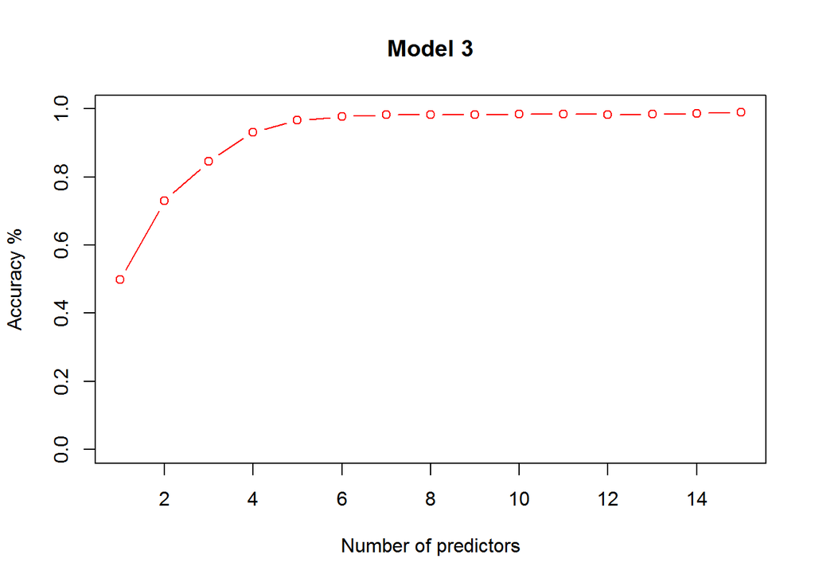

These 6 predictors are:

```
## [1] "roll_belt"         "yaw_belt"          "pitch_forearm"
## [4] "magnet_dumbbell_z" "pitch_belt"        "magnet_dumbbell_y"
```

## Predicting with testing dataset

```r
training_data=training[ ,which( names(training) %in% c(cols,"classe"))]
testing_data=testing[ ,which( names(testing) %in% cols)]

modFinal=randomForest(classe~., data=training_data, type="class")

#These are 100% accurate per submission.
p=predict(modFinal, testing_data)
print(p)
```

```
##  1  2  3  4  5  6  7  8  9 10 11 12 13 14 15 16 17 18 19 20
##  B  A  B  A  A  E  D  B  A  A  B  C  B  A  E  E  A  B  B  B
## Levels: A B C D E
```

## Conclusion

```
## [1] "roll_belt"         "yaw_belt"          "pitch_forearm"
## [4] "magnet_dumbbell_z" "pitch_belt"        "magnet_dumbbell_y"
```

## Results

```r
pml_write_files = function(x){
  n = length(x)
  for(i in 1:n){
    filename = paste0("problem_id_",i,".txt")
    write.table(x[i],file=filename,quote=FALSE,row.names=FALSE,col.names=FALSE)
  }
}
pml_write_files(p)
```